# Dinámica de una población sola

# Crecimiento geométrico o exponencial

> Una célula de Saccharomyces cerevisiae acaba de caer en un barril de mosto recién extraído. Su maquinaria metabólica se pone en marcha y enseguida está dispuesta a dividirse (en realidad, a multiplicarse). En solo 1.5 horas ya tenemos dos levaduras A las 3 horas habrá 4, después 8, 16 y así, así… **¿Se puede predecir la abundancia futura?**

En matemáticas, la secuencia ${1, 2, 4, 8, 16, ...}$ se llama *serie geométrica* y por eso se dice que la población de levaduras *crece geométricamente*. Es muy fácil calcular el número de levaduras que habrá después de $k$ divisiones
$$N_k = 2^k$$

## En función del tiempo

Para incluir el tiempo en la ecuación anterior solo hay que tener en cuenta el número de divisiones $k$ ocurridas después de $t$ horas: $k = \frac{t}{1.5}$ y entonces
$$N_t = 2^{\frac{t}{1.5}}$$
En general, para cualquier tiempo de duplicación $t_d$ podemos escribir
$$N_t = 2^{\frac{t}{t_d}}$$
Si queremos utilizar la base $e$ en vez del $2$ solo hay que tener en cuenta la definición de *logaritmo*: $2 = e^{\ln 2}$ y sustituir uno por otro
$$N_t = e^{\frac{\ln 2}{t_d}t}$$

## Tasa intrínseca de crecimiento *r*

Al cociente $\frac{\ln 2}{t_d}$ se le suele llamar *tasa intrínseca de crecimiento* y casi siempre se reprenta con la letra $r$. Así queda mucho mejor la ecuación
$$N_t = e ^{r t}$$
En el ejemplo introductorio de las levaduras el valor de $r$ es $\frac{\ln 2}{1.5} = 0.46 \; h^{-1}$. Estas unidades tan raras salen al dividir un número entre una magnitud de tiempo.

## Número inicial de individuos

Si en vez de $1$ hubiera un número inicial de individuos $N_0$ es fácil ver que la abundancia cambiaría proporcionalmente, así tendríamos $N_t = N_0 e ^{r t}$.

## Ecuación general del modelo exponencial

A partir de ahora, para simplificar las expresiones, siempre que aparezca la abundancia como función del tiempo escribiremos $N$ en vez de $N_t$, igual que escribimos $y = a + m x$ en vez de $y_x = a + m x$. Y llegamos a la ecuación más conocida de la dinámica de poblaciones:

$$N = N_0 e ^{r t}$$

## ¿Geométrico o exponencial?

El adjetivo *geométrico* se suele reservar para poblaciones cuyos individuos se reproducen simultáneamente cada cierto intervalo de tiempo $\Delta t$ y, entonces, la abundancia total aumenta de forma escalonada con la llegada de las nuevas *cohortes*. En este caso, solo tiene sentido evaluar la ecuación general cuando $t$ es múltiplo de $\Delta t$.

Cuando la reproducción ocurre a lo largo de un periodo indefinido de tiempo, los nuevos individuos llegan de forma continua y la población aumenta de manera progresiva. Aquí sí se puede utilizar la ecuación para cualquier valor de $t$ y se suele hablar de crecimiento *exponencial*. Sigamos con el ejemplo para verlo mejor:

> Sean 12 levaduras como la de antes en la misma situación. Como no son exactamente iguales, algunas se dividen un poco antes que otras, aunque el tiempo medio de división sigue siendo 1.5 horas porque los adelantos se compensan con los retrasos. **¿Cambia la ecuación anterior?**

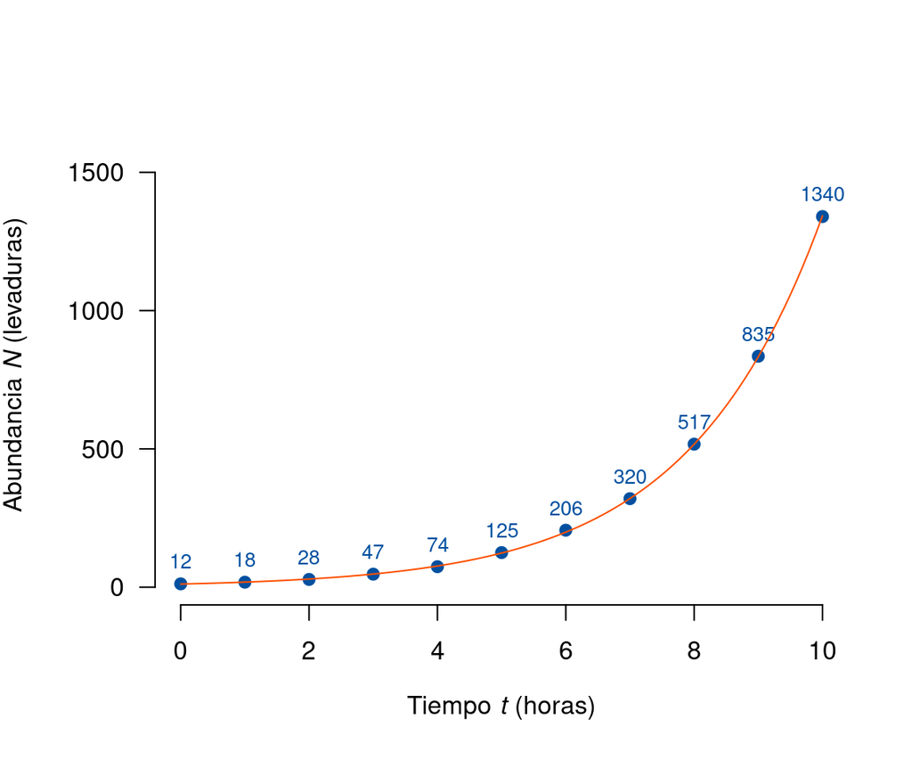

## Explora por ti mismo

[interactive chart not shown]

**Figura 2 (interactiva). Crecimiento exponencial.** Mueve los puntos azules y observa cómo cambia la función exponencial. También puedes mover el segmento rojo que representa el tiempo de duplicación poblacional para comprobar que es el mismo en cualquier momento.

### Las cotorras argentinas de Málaga

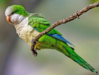

Parece que este inteligente loro ha encontrado un hábitat muy agradable en tierras malagueñas y su población está aumentando exponencialmente según se cuenta en este [artículo](https://dialnet.unirioja.es/descarga/articulo/7235478.pdf).

En muy poco tiempo se ha convertido en una especie muy abundante gracias a su capacidad de adaptación y la ausencia de depredadores.

Efectivamente, cuando se representan las observaciones de cada año aparece una tendencia exponencial:

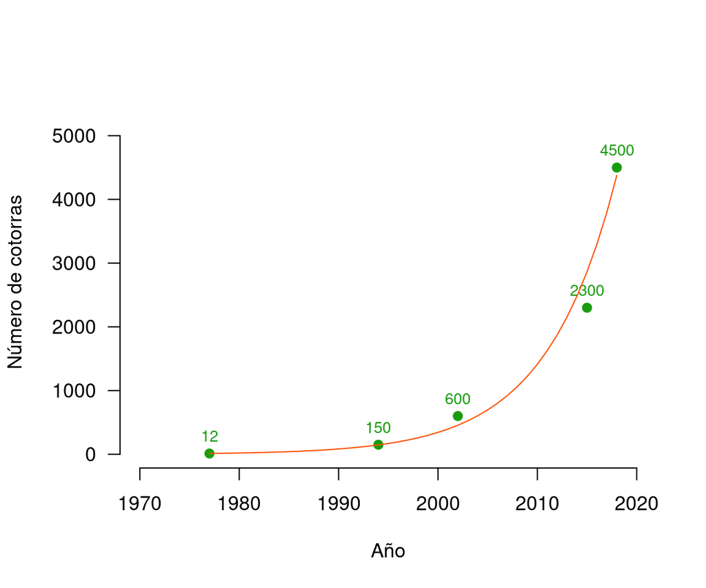

**Dinámica temporal de la población de cotorras en la provincia de Málaga.** Los puntos verdes son los datos que aparecen [aquí](https://dialnet.unirioja.es/descarga/articulo/7235478.pdf) y la curva naranja es el ajuste exponencial. Parece que se aproximan bastante bien.

> Vamos a calcular su tasa intrínseca de crecimiento
1. La ecuación exponencial se transforma en una recta si se toma el logaritmo natural a cada lado:
   $$\begin{align}
   \ln N &= \ln(N_0 e ^{r t}) \\[1em]
   \ln N &= \ln N_0 + r t
   \end{align}$$
   La pendiente de esa recta es $r$. Así que calculamos el logaritmo de las abundancias.

| Año (t) | Individuos (N) | ln N |
| --- | --- | --- |
| 1977 | 12 | 2.48 |
| 1994 | 150 | 5.01 |
| 2002 | 600 | 6.40 |
| 2015 | 2300 | 7.74 |
| 2018 | 4500 | 8.41 |

2. Representamos $\ln N$ en función de $t$. Vemos que los puntos se alinean en una recta que ajustamos mediante mínimos cuadrados.

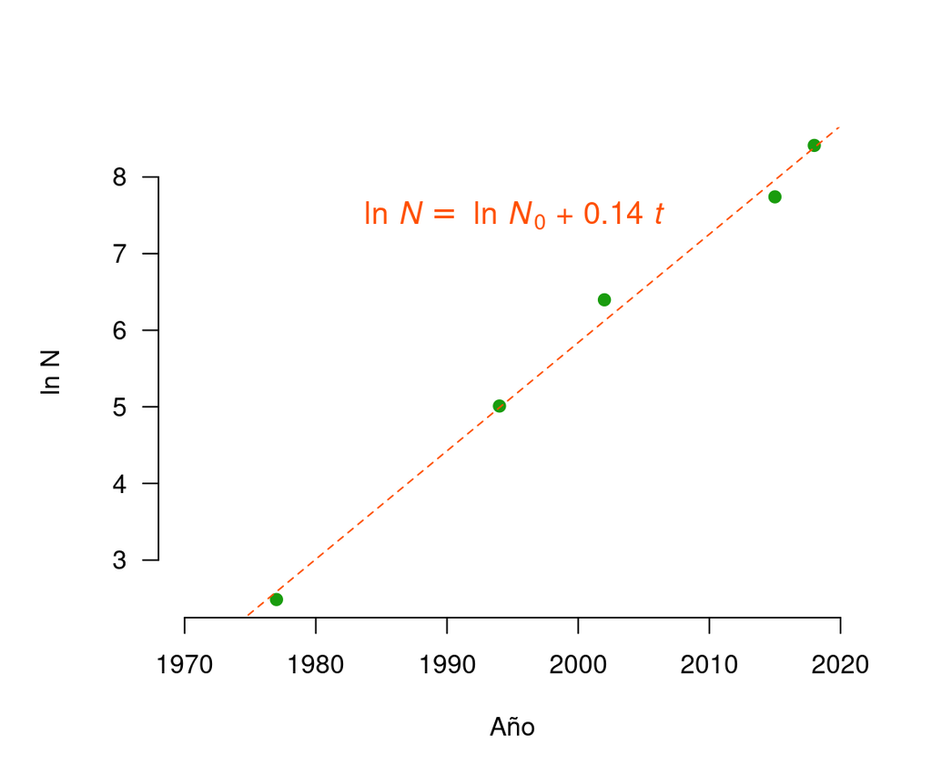

3. La pendiente de la recta (0.14) es justamente el valor de $r$. Como el tiempo está en años, decimos que $r$ = *0.14 años⁻¹*.

Según hemos visto antes, el tiempo de duplicación será 4.9 años. Entonces, como en 2018 había 4500 cotorras, de seguir así la tendencia en 2023 habrá 9000.

# Ecuación discreta

A veces interesa expresar la abundancia futura en función de la abundancia actual, en vez de en función del tiempo. En el caso del crecimiento exponencial se cumple que

$$N_1 = \lambda N_0$$

donde $\lambda$ es un factor de proporción que siempre permanece constante. Esto quiere decir que la abundancia de una población creciendo exponencialmente aumenta en el mismo factor cada vez que transcurre una unidad de tiempo (la que sea).

Es muy fácil demostrar que

$$N_t = \lambda^t N_0$$

donde $t$ es el número de unidades de tiempo transcurrido.

A diferencia de $r$, el coeficiente $\lambda$ no tiene unidades porque es un factor de proporción, un cociente entre abundancias consecutivas en el tiempo.

## Relación entre *λ* y *r*

Al comparar estas dos ecuaciones

$$N_t = N_0 e^{r t} \qquad N_t = \lambda^t N_0$$

vemos que $e^r = \lambda$, o también

$$r = \ln \lambda$$

Estrictamente hablando, es $r = \frac{\ln \lambda}{\Delta t}$, siendo $\Delta t$ el intervalo de tiempo sobre el que se define $\lambda$; solo así se logra la coherencia de unidades. Como habitualmente $\Delta t = 1$, se suele obviar esta precisión.

# Ecuación diferencial

Las ecuaciones que dan directamente $N$ en función de $t$ son faćiles de entender en poblaciones solas. Sin embargo, cuando los individuos interaccionan con otros elementos, la cosa se complica. De hecho, muchas veces no es que sea complicado sino que es imposible obtener una ecuación directa como la de antes.

#### Deducción de la ecuación diferencial

Para encontrar la forma diferencial tenemos que derivar la ecuación conocida
$$N = N_0 e^{r t}$$
En términos mátemáticos, encontrar la derivada de $N$ con respecto a $t$. Veamos:

1. Derivamos cada lado de la ecuación
   $$\frac{d N}{d t} = \frac{d \left(N_0 e^{rt}\right)}{d t}$$
2. La parte derecha es una derivada sencilla (constante por composición de funciones)
   $$\frac{d \left(N_0 e^{rt}\right)}{d t} = N_0 \frac{d \left(e^{rt}\right)}{d t} = N_0 \, r \, e^{r t}$$
3. Date cuén de que
   $$N_0 \, r \, e^{r t} = r \, N_0 \, e^{r t} = r N$$
4. Y finalmente

   $$\frac{d N}{d t} = r N$$

   que expresa la característica esencial de una curva exponencial: *su derivada es proporcional a ella misma*.

Como puedes ver, es lo más sencillo que se despacha en ecuaciones diferenciales. Esta sencillez la coloca como primera piedra en la dinámica de poblaciones porque a partir de ella surgen casi todos los demás modelos.

> Esta sencilla ecuación muestra el potencial de cualquier población: **la velocidad de crecimiento es proporcional a la propia abundancia.**

# Significado de *r*

Matemáticamente hablando no hay duda: $r$ es el factor de proporción entre la velocidad de crecimiento de una población y su abundancia. En términos biológicos es muy difícil percibir este significado porque la poblaciones rara vez crecen de forma exponencial.

No obstante, el potencial está ahí. Por eso se llama *intrínseca* a esta constante: cualquier población, en el ambiente más propicio, crecería con una $r$ característica de su especie, aunque nunca estemos seguros de si $r$ es propia de la especie, del individuo o de la población. Cuando no se dan esas circunstancias –que es lo habitual– $r$ sigue presente y se manifiesta en la velocidad de respuesta a los cambios ambientales, así que es un coeficiente de interés biológico excepcional, aunque difícil de interpretar.

## Los componentes de *r*

En abstracto, $r$ es un balance entre las fuerzas reproductivas y mortíferas que gobiernan la población, de modo que

$$r = b - m$$

Al desarrollar esto en la ecuación diferencial, obtenemos

$$\frac{dN}{dt} = b N - m N$$

y podemos decir que $b N$ y $m N$ son, respectivamente, las velocidades con que ocurren nacimientos y muertes en la población.

En el modelo más sencillo que nos ocupa, $b$ y $m$ son constantes. Ya veremos más adelante que ambas fuerzas están sometidas a diversos factores que controlan el desarrollo de las poblaciones y, entonces, ya no serán fijas.

#### Modelo exponencial estocástico

Dos poblaciones pueden crecer con la misma $r$ y, sin embargo, tener distintas tasas de natalidad y mortalidad. El modelo determinista es insensible a esta peculiaridad pero biológicamente no debería ser así: una población que está sometida a una alta mortalidad y, por tanto, debe invertir mucha energía la reproducción debería estar más expuesta a la extinción que otra población con menores velocidades demográficas. Veamos esto en un experimento estocástico.

Sea una población de tamaño $N$ y tasas de nacimiento y mortalidad $b$ y $m$, respectivamente. Los sucesos que ocurran en la población seguirán una secuencia aleatoria dependiente de la probabilidad de cada caso: nacimiento (`B`) o muerte (`M`). Por ejemplo, empezamos con $N = 5$ individuos y se produce la secuencia de sucesos `B, M, M, B, B, B, B, B, B, B` que se manifestará en forma de la siguiente dinámica temporal $N = \{6, 5, 4, 5, 6, 7, 8, 9, 10, 11\}$.

##### Frecuencia y probabilidad de nacimiento o muerte

La frecuencia de nacimientos será $b N$ y la de muertes $m N$. La frecuencia con la que acontecen sucesos (ya sean nacimientos o muertes) es la suma de ambas

$$f = (b + m) N$$

entonces, definimos la probabilidad de un suceso en función del cociente entre su frecuencia y la frecuencia total:

$$\begin{align}
\operatorname{P}[nacimiento] &= \frac{b N}{(b + m) N} = \frac{b}{b + m} \\[1em]
\operatorname{P}[muerte] &= \frac{m N}{(b + m) N} = \frac{m}{b + m}
\end{align}$$

##### Tiempo intermedio entre sucesos

Por otro lado, el tiempo intermedio entre dos sucesos consecutivos será el inverso de la frecuencia de sucesos:

$$\Delta t = \frac{1}{f}$$

Veamos un ejemplo.

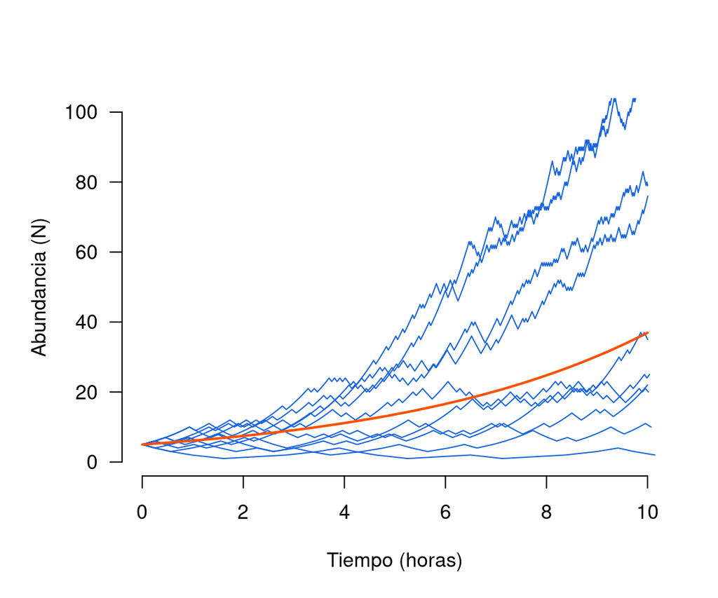

**Dinámica exponencial estocástica.** Las líneas azules representan 10 simulaciones estocásticas de una población con $N_0$ = 5, $b$ = 0.5 h⁻¹ y $m$ = 0.3 h⁻¹. La línea naranja corresponde al modelo determinista equivalente $N = N_0 e^{0.2 t}$.

Aunque todas las simulaciones muestran la misma tendencia ascendente, algunas poblaciones se adelantan y otras se retrasan. Podemos hacer un estudio estadístico más robusto con más simulaciones:

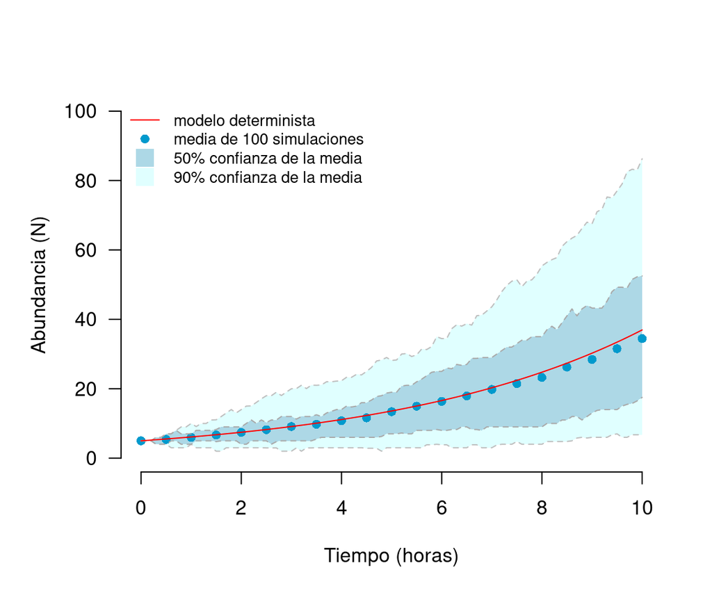

**Comparación entre el modelo estocástico y el determinista.** En las mismas condiciones que antes, los puntos azules representan la media de 100 simulaciones para algunos tiempos escogidos y la línea naranja el valor determinista. La banda azul oscuro representa el 50 % de confianza de la media, la banda azul claro representa el 90 %.

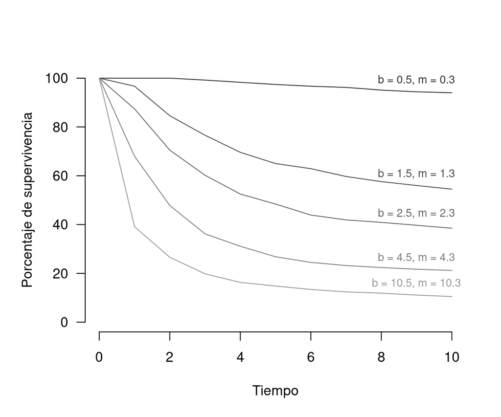

**Supervivencia de una población estocástica.** En las mismas condiciones que antes, con el mismo $N_0$ y la misma $r$ pero con distintas combinaciones de $b$ y $m$. Cuanto mayores son estos coeficientes, menor es la probabilidad de que la población sobreviva hasta cierto tiempo.

> Este resultado concuerda con nuestra intuición biológica: una población que invierte muchos recursos en crecer y sufre una alta tasa de mortalidad está mucho más expuesta a la extinción que otra población más eficiente en el balance nacimientos/muertes.

# Ejercicios selectos

## 2. Los pulgones

Un terrario ha sido colonizado recientemente por *Hyadaphis malacitana* y, debido al excelente microclima, ha entrado en el ciclo de reproducción partenogénica. Hace un mes había 242 individuos y, desde entonces, han nacido 40 y han muerto 15.

1. ¿Cuánto vale $r$?
2. Si la cosa sigue así, ¿cuántos pulgones habrá dentro de seis meses a partir de ahora?

## 3. La cerveza

Dos avispados estudiantes de biología pretendían fabricar cerveza artesanal. Sospechaban que la cantidad inicial de malta debía de ser importante así que, antes de lanzarse a la piscina, probaron dos concentraciones de mosto inoculados con la misma cantidad de levaduras, controlando diariamente la densidad de células con un Coulter-Counter. Aquí los resultados de los primeros cinco días:

| Experimento | día 1 | día 2 | día 3 | día 4 | día 5 |
| --- | --- | --- | --- | --- | --- |
| A (poca malta) | 510 | 2700 | 5600 | 14000 | 50000 |
| B (mucha malta) | 480 | 4500 | 19000 | 76000 | 260000 |

1. Representa el logaritmo de $N$ en función del tiempo para estimar $r$ en cada experimento.
2. ¿Podemos decir cuánto vale la *tasa intrínseca de crecimiento* de la cepa utilizada?

## 4. El solar

En un solar que ha quedado abandonado durante la expansión de la universidad están creciendo matojos a un ritmo del 19 % anual.

1. ¿Cuál es el tiempo de duplicación medio de esa comunidad de herbáceas?
2. ¿Cuánto vale $\lambda$ si aplicamos el intervalo anual?

## 5. El visón americano

En 1990 se escaparon un número indeterminado de visones de una granja peletera. A los dos años empezaron a verse ejemplares por el territorio y desde entonces, se está haciendo un seguimento cada seis años de los avistamientos. La figura muestra la evolución temporal del área potencialmente ocupada.

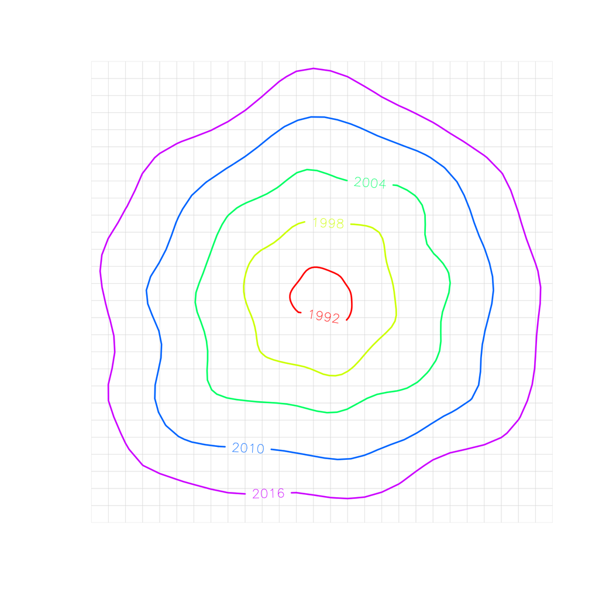

1. ¿Se puede calcular $r$ en la población?
2. ¿Y el número total de visones?